# Split Times F30_1_29

- Show All Code
- Hide All Code
- View Source

Author

Affiliation

Ruxin Shi

Michigan State University, Statistics and Probability

Published

2024-01-29 20:51:57 EST

Modified

2024-01-29 20:51:46 EST

# 1 Purpose

This file provides results of MR-SPLIT including type I error and power comparison when applying different split times.

# 2 Simulation

This section provides the codes used to simulate the results.

## 2.1 Define Global Options

Global R chunk options are defined in the YAML header but local chunk options will over-ride global options. We can temporarily disable an individual chunk by inserting `#| eval = FALSE` on a line at the top of the chunk. The method for creating a `cfsize` option that controls font size in code chunks and their text output is based on an answer to a question posted on [stackoverflow.com](https://stackoverflow.com/a/46526740).

````markdown
```{r}
#| label: global-options
#| cfsize: footnotesize

# Create a custom chunk hook/option for controlling font size in chunk & output.
# Global value for this is set in YAML header.
def.chunk.hook  <- knitr::knit_hooks$get("chunk")
knitr::knit_hooks$set(chunk = function(x, options) {
  x <- def.chunk.hook(x, options)
  ifelse(options$cfsize != "normalsize",
         paste0("\n \\", options$cfsize,"\n\n", x, "\n\n \\normalsize"),
         x)
  })
```
````

## 2.2 Declare Path

This next chunk declares the path to this script relative to the project-level root directory. If the file is not in the right location under the project root you’ll get a warning message. This helps ensure relative paths are all working as expected.

````markdown
```{r}
#| label: declare-path

# Declare path to this script relative to the project root directory.
here::i_am(path = paste0(params$SourceDir, params$SourceFile))
```
````

```
here() starts at C:/Users/shirx/OneDrive/Desktop/Major
```

Note that `here()` creates a path relative to the location of the `EFNEPCBA.proj` file that will be portable across local repositories on different computers. That’s why we use that function when specifying file paths throughout the script.

## 2.3 Load Packages

Load R packages that we need to get additional functions.

````markdown
```{r}
#| label: load-packages

library(ivreg)
library(MASS)
library(ggplot2)
library(hdi)
```
```{r}
#| label: load-packages

library(glmnet)
```
```{r}
#| label: load-packages

library(dplyr)
```
```{r}
#| label: load-packages

library(qqman)
```
````

```
For example usage please run: vignette('qqman')
```

```
Citation appreciated but not required:
```

```
Turner, (2018). qqman: an R package for visualizing GWAS results using Q-Q and manhattan plots. Journal of Open Source Software, 3(25), 731, https://doi.org/10.21105/joss.00731.
```

````markdown
```{r}
#| label: load-packages

library(screening)
library(foreach)
library(doParallel)
```
```{r}
#| label: load-packages

library(kableExtra)
```
```{r}
#| label: load-packages

library(quarto)           # for quarto_version()
library(gridExtra)
```
````

## 2.4 Setting

The chunk below shows the settings.

````markdown
```{r}
#| label: setting
#| eval: true
weightcal=function(weight){
  len=length(weight)
  a=(weight>=0)
  b=abs(weight)/sum(abs(weight))
  c=NULL
  for(i in 1:len){
    if(a[i])c[i]=b[i]
    if(!a[i])c[i]=-1*b[i]
  }
  return(c)
}
#Y outcome, D exposure
#Z instruments, X covariates
J=300 #number of SNPs
J1=5 #useful SNPs
N=c(500,1000,2000) #sample size
mul=100
MAF=0.3 #minor allele frequency
Times=1000
rho=0.1
squareh=c(0.15,0.2,0.3)#extremely weak, weak, moderate
ratio=matrix(0,nrow=5,ncol=2)
ratio[,1]=c(0.4,0.4,0.1,0.05,0.05)
ratio[,2]=c(0.2,0.2,0.2,0.2,0.2)
beta=0.2 #causal effect, 0 when type I error
k=2
```
````

## 2.5 Simulation

The chunk below shows the simulation process.

````markdown
```{r}
#| label: simulate
#| eval: false
set.seed(1)
cl <- makeCluster(50)
registerDoParallel(cl)
for(rr in 1:2){
  for(ii in 1:length(N)){
    for(hh in 1:3){
      #MAJOR
      for(Times in 1:100){
        results <- foreach(t=((Times-1)*10+1):(Times*10), .combine=rbind, .packages=c('ivreg','MASS','glmnet','dplyr','qqman','screening','ivmodel')) %dopar% {
          point.est=matrix(NA,ncol=5,nrow=mul)
          point.est[,1]=rep(t,mul)
          G=matrix(0,nrow=N[ii],ncol=J)
          for(i in 1:J){
            maf=MAF[i%%length(MAF)]
            if(i%%length(MAF)==0)maf=MAF[length(MAF)]
            GG1=runif(N[ii],min=0,max=1)
            GG1[GG1<=(1-maf)^2]=0
            GG1[GG1>(1-maf^2)]=2
            GG1[which(GG1!=0&GG1!=2)]=1
            G[,i]=GG1
          }
          Sigma=matrix(c(1,rho,rho,1),nrow=2,ncol=2)
          sumsquarepi=squareh[hh]*Sigma[2,2]/(1-squareh[hh])/(2*MAF*(1-MAF))
          pi=sqrt(sumsquarepi*ratio[,rr])
          error=mvrnorm(N[ii],mu=c(0,0),Sigma=Sigma)
          real=sample(c(1:J),size=J1,replace = FALSE)
          Greal=G[,real]
          X=as.matrix(Greal)%*%as.matrix(pi)+error[,1]
          Y=X*beta+error[,2]
          for(tt in 1:mul){
            #split sample
            selected=NULL
            unselected=1:N[ii]
            n=sample(unselected,size=N[ii]/k,replace = FALSE)
            selected=cbind(selected,n)
            for(p in 1:k){
              if(p<k){
                n=sample(unselected[-selected],size=N[ii]/k,replace = FALSE)
                selected=cbind(selected,n)
              }
            }
            #select IVs using SIS
            selectIV=list()
            for(p in 1:k){
              n=selected[,p]
              if(J<N[ii]/2){
                fit=screening(G[-n,],X[-n],method = "sis",num.select = 100)
              }
              if(J>N[ii]/2){
                fit=screening(G[-n,],X[-n],method = "sis")
              }
              selectIV[[p]]=fit$screen
            }
            #LASSO
            weights=list()
            for(p in 1:k){
              n=selected[,p]
              #select IVs
              lambda=cv.glmnet(G[-n,selectIV[[p]]],X[-n],alpha=1)$lambda.min
              lasso=glmnet(G[-n,selectIV[[p]]],X[-n],lambda=lambda)
              #coef of all IVs
              a=coef(lasso)[-1,]
              while(length(a[a!=0])==0){
                lambda=cv.glmnet(G[-n,selectIV[[p]]],X[-n],alpha=1)$lambda.min
                lasso=glmnet(G[-n,selectIV[[p]]],X[-n],lambda=lambda)
                #coef of all IVs
                a=coef(lasso)[-1,]
              }
              weights[[p]]=a[a!=0]
              #selected IVs
              selectIV[[p]]=selectIV[[p]][a!=0]
            }
            #select major and weak based on partial F statistics
            partialF=list()
            for(p in 1:k){
              n=selected[,p]
              full=lm(X[-n]~G[-n,selectIV[[p]]])
              Fs=NULL
              if(length(selectIV[[p]])==1){
                Fs=summary(lm(X[-n]~G[-n,selectIV[[p]]]))$fstat[1]
              }
              if(length(selectIV[[p]])>1){
                for(q in 1:length(selectIV[[p]])){
                  reduced=lm(X[-n]~G[-n,selectIV[[p]][-q]])
                  Fs[q]=anova(reduced,full)$F[2]
                }
              }
              partialF[[p]]=Fs
            }
            selectmajor=list()
            selectweak=list()
            for(p in 1:k){
              selectmajor[[p]]=selectIV[[p]][partialF[[p]]>=30]
              selectweak[[p]]=selectIV[[p]][partialF[[p]]<30]
            }

            #Get coef
            combineMajor=list()
            for(p in 1:k){
              n=selected[,p]
              weakwei=weights[[p]][partialF[[p]]<30]
              if(length(weakwei)>1){
                weakwei=weightcal(weakwei)
                combineMajor[[p]]=cbind(G[n,selectmajor[[p]]],G[n,selectweak[[p]]]%*%weakwei)
              }
              if(length(weakwei)<=1) combineMajor[[p]]=G[n,selectIV[[p]]]
            }
            #MAJOR
            hatX=NULL
            for(p in 1:k){
              n=selected[,p]
              fit=lm(X[n]~combineMajor[[p]])
              hatX=c(hatX,fit$fitted.values)
            }
            fit2=lm(Y[c(selected)]~hatX)
            point.est[tt,2:5]=summary(fit2)$coef[2,1:4]
          }
          return(point.est)
        }
        colnames(results)=c("Times","Estimates","Std","t value","Pr")
        write.table(results,file=paste0("CFMR/results/split times/F30_multiple_0.2_rr",rr,"h_",squareh[hh],"N_",N[ii],"Times_",Times,".txt"),row.names = FALSE,col.names = FALSE)

      }
       }
  }
}
stopCluster(cl)
```
````

# 3 Results

The chunk below shows how I combine all the results.

````markdown
```{r}
#| label: combine
#| eval: false
setwd("C:/Users/shirx/OneDrive/Desktop/Major/Simulation study/results/split times")
#beta=0.2
for(rr in 1:1){
  for(ii in 1:length(N)){
    for(hh in 3:3){
      Estimates=matrix(0,nrow=1000,ncol=mul)
      p.value=matrix(0,nrow=1000,ncol=mul)
      for(Times in 1:100){
       file=paste0("F30_multiple_0.2_rr",rr,"h_",squareh[hh],"N_",N[ii],"Times_",Times,".txt")
       data=read.table(file = file)
       for(tt in 1:10){
         Data=matrix(0,nrow=mul,ncol=2)
         for(ran in 1:mul){
          sam=sample(1:mul,size=ran)
          split=data[data[,1]==(Times-1)*10+tt,][sam,]
          if(ran>=2){
            T1=mean(tan((0.5-split[,5])*pi))
            p1=0.5-atan(T1)/pi
            Data[ran,]=c(mean(split[,2]),p1)
          }
          if(ran==1){
            Data[ran,]=as.matrix(split[,c(2,5)])
          }
         }
         Estimates[(Times-1)*10+tt,]=c(Data[,1])
         p.value[(Times-1)*10+tt,]=c(Data[,2])
       }
      }
      power=NULL
      for(ran in 1:mul){
        power[ran]=sum(p.value[,ran]<0.05)/1000
      }
      write.table(Estimates,paste0("Estimates_0.2_rr",rr,"h_",squareh[hh],"N_",N[ii],".txt"))
      write.table(p.value,paste0("pvalue_0.2_rr",rr,"h_",squareh[hh],"N_",N[ii],".txt"))
     }
  }
}
#beta=0
for(rr in 1:1){
  for(hh in 3:3){
  for(ii in 1:length(N)){

      Estimates=matrix(0,nrow=1000,ncol=mul)
      p.value=matrix(0,nrow=1000,ncol=mul)
      for(Times in 1:100){
       file=paste0("F30_multiple_0_rr",rr,"h_",squareh[hh],"N_",N[ii],"Times_",Times,".txt")
       data=read.table(file = file)
       for(tt in 1:10){
         Data=matrix(0,nrow=mul,ncol=2)
         for(ran in 1:mul){
          sam=sample(1:mul,size=ran)
          split=data[data[,1]==(Times-1)*10+tt,][sam,]
          if(ran>=2){
            T1=mean(tan((0.5-split[,5])*pi))
            p1=0.5-atan(T1)/pi
            Data[ran,]=c(mean(split[,2]),p1)
          }
          if(ran==1){
            Data[ran,]=as.matrix(split[,c(2,5)])
          }
         }
         Estimates[(Times-1)*10+tt,]=c(Data[,1])
         p.value[(Times-1)*10+tt,]=c(Data[,2])
       }
      }
      power=NULL
      for(ran in 1:mul){
        power[ran]=sum(p.value[,ran]<0.05)/1000
      }
      write.table(Estimates,paste0("Estimates_0_rr",rr,"h_",squareh[hh],"N_",N[ii],".txt"))
      write.table(p.value,paste0("pvalue_0_rr",rr,"h_",squareh[hh],"N_",N[ii],".txt"))
     }
  }
}
```
````

Figure 1, Figure 2 and Figure 3 shows the how power increasing as the split times increasing. When the sample size is small (N=500) and the IVs are extremely weak($h^2=0.15$), after 60 splits, the increase in power tends to stabilize. In other words, it takes 60 splits to achieve an optimal power. As the IVs become stronger and the sample size increases, the required number of splits can be reduced.

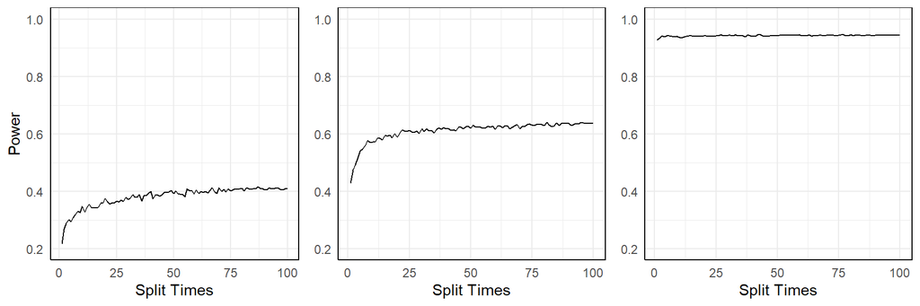

Figure 1: Power when h2=0.15 and N=500(left), 1000(middle), 2000(right) in Scenario I

````markdown
```{r fig.width=9, fig.height=3}
#| label: fig-power_h_1
#| eval: true
#| fig-cap: Power when h2=0.15 and N=500(left), 1000(middle), 2000(right) in Scenario I

#Power
hh=1
rr=1

plots <- list()

for (ii in 1:3) {
  Estimates <- read.table(paste0("results/split times/Estimates_0.2_rr", rr, "h_", squareh[hh], "N_", N[ii], ".txt"))
  p.value <- read.table(paste0("results/split times/pvalue_0.2_rr", rr, "h_", squareh[hh], "N_", N[ii], ".txt"))

  power <- NULL
  for (ran in 1:mul) {
    power[ran] <- sum(p.value[, ran] < 0.05) / 1000
  }

  power_df <- data.frame(SplitTimes = 1:mul, Power = power)

  p <- ggplot(power_df, aes(x = SplitTimes, y = Power)) +
    geom_line() +
    theme_minimal() +
    theme(panel.border = element_rect(colour = "black", fill=NA),
          axis.line = element_line()) +
    labs(x = "Split Times", y = NULL, main = NULL)+
    scale_y_continuous(limits =c(0.2,1))

  if (ii != 1) {
    p <- p + theme(axis.title.y = element_blank())
  } else {
    p <- p + labs(y = "Power")
  }

  plots[[ii]] <- p
}

grid.arrange(grobs = plots, ncol = 3)
```
````

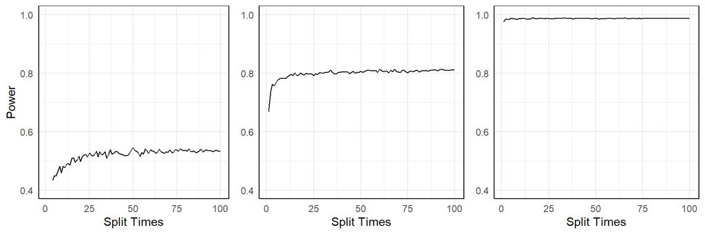

Figure 2: Power when h2=0.2 and N=500(left), 1000(middle), 2000(right) in Scenario I

````markdown
```{r fig.width=9, fig.height=3}
#| label: fig-power_h_2
#| eval: true
#| fig-cap: Power when h2=0.2 and N=500(left), 1000(middle), 2000(right) in Scenario I

#Power
hh=2
rr=1

plots <- list()

for (ii in 1:3) {
  Estimates <- read.table(paste0("results/split times/Estimates_0.2_rr", rr, "h_", squareh[hh], "N_", N[ii], ".txt"))
  p.value <- read.table(paste0("results/split times/pvalue_0.2_rr", rr, "h_", squareh[hh], "N_", N[ii], ".txt"))

  power <- NULL
  for (ran in 1:mul) {
    power[ran] <- sum(p.value[, ran] < 0.05) / 1000
  }

  power_df <- data.frame(SplitTimes = 1:mul, Power = power)

  p <- ggplot(power_df, aes(x = SplitTimes, y = Power)) +
    geom_line() +
    theme_minimal() +
    theme(panel.border = element_rect(colour = "black", fill=NA),
          axis.line = element_line()) +
    labs(x = "Split Times", y = NULL, main = NULL)+
    scale_y_continuous(limits =c(0.4,1))

  if (ii != 1) {
    p <- p + theme(axis.title.y = element_blank())
  } else {
    p <- p + labs(y = "Power")
  }

  plots[[ii]] <- p
}

grid.arrange(grobs = plots, ncol = 3)
```
````

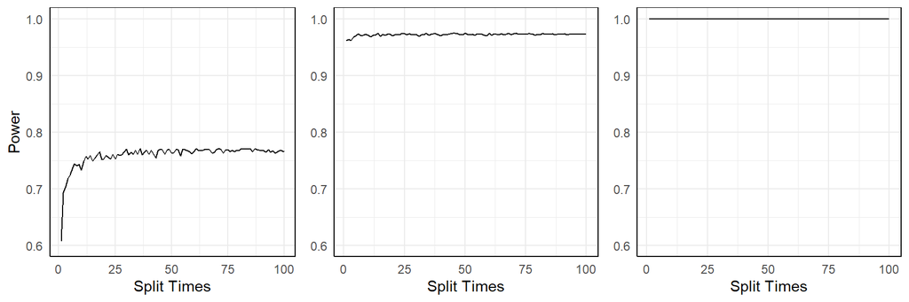

Figure 3: Power when h2=0.3 and N=500(left), 1000(middle), 2000(right) in Scenario I

````markdown
```{r fig.width=9, fig.height=3}
#| label: fig-power_h_3
#| eval: true
#| fig-cap: Power when h2=0.3 and N=500(left), 1000(middle), 2000(right) in Scenario I

#Power
hh=3
rr=1

plots <- list()

for (ii in 1:3) {
  Estimates <- read.table(paste0("results/split times/Estimates_0.2_rr", rr, "h_", squareh[hh], "N_", N[ii], ".txt"))
  p.value <- read.table(paste0("results/split times/pvalue_0.2_rr", rr, "h_", squareh[hh], "N_", N[ii], ".txt"))

  power <- NULL
  for (ran in 1:mul) {
    power[ran] <- sum(p.value[, ran] < 0.05) / 1000
  }

  power_df <- data.frame(SplitTimes = 1:mul, Power = power)

  p <- ggplot(power_df, aes(x = SplitTimes, y = Power)) +
    geom_line() +
    theme_minimal() +
    theme(panel.border = element_rect(colour = "black", fill=NA),
          axis.line = element_line()) +
    labs(x = "Split Times", y = NULL, main = NULL)+
    scale_y_continuous(limits =c(0.6,1))

  if (ii != 1) {
    p <- p + theme(axis.title.y = element_blank())
  } else {
    p <- p + labs(y = "Power")
  }

  plots[[ii]] <- p
}

grid.arrange(grobs = plots, ncol = 3)
```
````

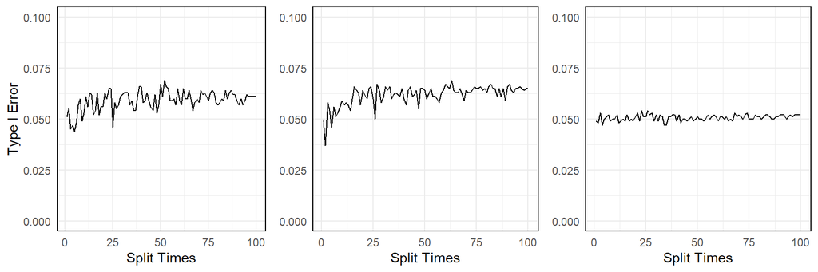

Figure 4: Type I error when h2=0.15 and N=500(left), 1000(middle), 2000(right) in Scenario I

````markdown
```{r fig.width=9, fig.height=3}
#| label: fig-error_h_1
#| eval: true
#| fig-cap: Type I error when h2=0.15 and N=500(left), 1000(middle), 2000(right) in Scenario I

#Type I error
hh=1
rr=1
plots <- list()

for (ii in 1:3) {
  Estimates <- read.table(paste0("results/split times/Estimates_0_rr", rr, "h_", squareh[hh], "N_", N[ii], ".txt"))
  p.value <- read.table(paste0("results/split times/pvalue_0_rr", rr, "h_", squareh[hh], "N_", N[ii], ".txt"))

  power <- NULL
  for (ran in 1:mul) {
    power[ran] <- sum(p.value[, ran] < 0.05) / 1000
  }

  power_df <- data.frame(SplitTimes = 1:mul, Power = power)

  p <- ggplot(power_df, aes(x = SplitTimes, y = Power)) +
    geom_line() +
    theme_minimal() +
    theme(panel.border = element_rect(colour = "black", fill=NA),
          axis.line = element_line()) +
    labs(x = "Split Times", y = NULL, main = NULL)+
    scale_y_continuous(limits =c(0,0.1))

  if (ii != 1) {
    p <- p + theme(axis.title.y = element_blank())
  } else {
    p <- p + labs(y = "Type I Error")
  }

  plots[[ii]] <- p
}

grid.arrange(grobs = plots, ncol = 3)
```
````

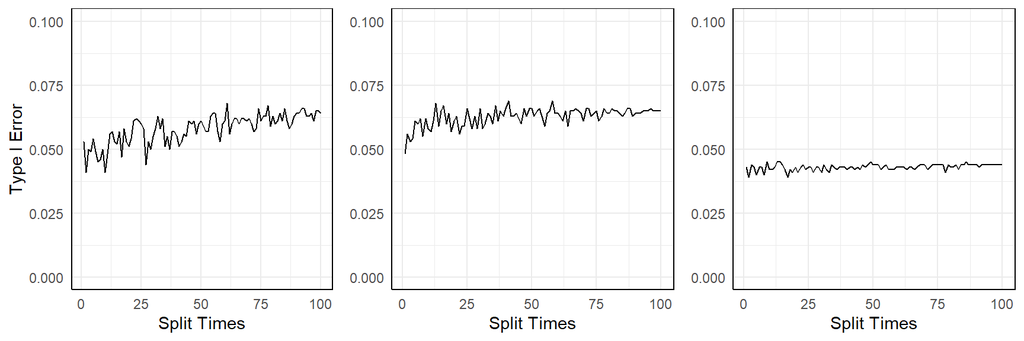

Figure 5: Type I error when h2=0.2 and N=500(left), 1000(middle), 2000(right) in Scenario I

````markdown
```{r fig.width=9, fig.height=3}
#| label: fig-error_h_2
#| eval: true
#| fig-cap: Type I error when h2=0.2 and N=500(left), 1000(middle), 2000(right) in Scenario I

#Type I error
hh=2
rr=1
plots <- list()

for (ii in 1:3) {
  Estimates <- read.table(paste0("results/split times/Estimates_0_rr", rr, "h_", squareh[hh], "N_", N[ii], ".txt"))
  p.value <- read.table(paste0("results/split times/pvalue_0_rr", rr, "h_", squareh[hh], "N_", N[ii], ".txt"))

  power <- NULL
  for (ran in 1:mul) {
    power[ran] <- sum(p.value[, ran] < 0.05) / 1000
  }

  power_df <- data.frame(SplitTimes = 1:mul, Power = power)

  p <- ggplot(power_df, aes(x = SplitTimes, y = Power)) +
    geom_line() +
    theme_minimal() +
    theme(panel.border = element_rect(colour = "black", fill=NA),
          axis.line = element_line()) +
    labs(x = "Split Times", y = NULL, main = NULL)+
    scale_y_continuous(limits =c(0,0.1))

  if (ii != 1) {
    p <- p + theme(axis.title.y = element_blank())
  } else {
    p <- p + labs(y = "Type I Error")
  }

  plots[[ii]] <- p
}

grid.arrange(grobs = plots, ncol = 3)
```
````

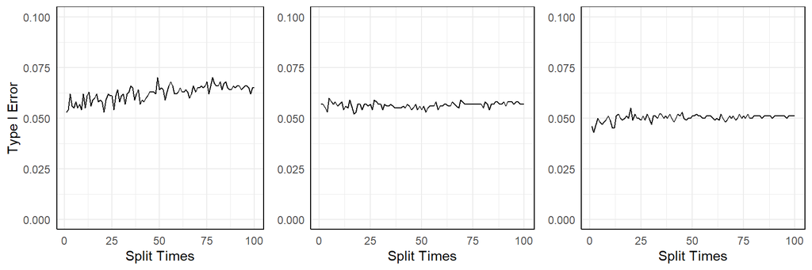

Figure 6: Type I error when h2=0.3 and N=500(left), 1000(middle), 2000(right) in Scenario I

````markdown
```{r fig.width=9, fig.height=3}
#| label: fig-error_h_3
#| eval: true
#| fig-cap: Type I error when h2=0.3 and N=500(left), 1000(middle), 2000(right) in Scenario I

#Type I error
hh=3
rr=1
plots <- list()

for (ii in 1:3) {
  Estimates <- read.table(paste0("results/split times/Estimates_0_rr", rr, "h_", squareh[hh], "N_", N[ii], ".txt"))
  p.value <- read.table(paste0("results/split times/pvalue_0_rr", rr, "h_", squareh[hh], "N_", N[ii], ".txt"))

  power <- NULL
  for (ran in 1:mul) {
    power[ran] <- sum(p.value[, ran] < 0.05) / 1000
  }

  power_df <- data.frame(SplitTimes = 1:mul, Power = power)

  p <- ggplot(power_df, aes(x = SplitTimes, y = Power)) +
    geom_line() +
    theme_minimal() +
    theme(panel.border = element_rect(colour = "black", fill=NA),
          axis.line = element_line()) +
    labs(x = "Split Times", y = NULL, main = NULL)+
    scale_y_continuous(limits =c(0,0.1))

  if (ii != 1) {
    p <- p + theme(axis.title.y = element_blank())
  } else {
    p <- p + labs(y = "Type I Error")
  }

  plots[[ii]] <- p
}

grid.arrange(grobs = plots, ncol = 3)
```
````

# 4 Software Information

This section documents information that is important for reproducibility. Most users will not need to read it. It is primarily here for use by the statistician on the team.

We used [R](https://www.r-project.org/) as our main computing environment and [Quarto](https://quarto.org/) scripts to enhance reproducibility. We used RStudio as the editor to interface with R and Quarto.

- Software chain: **qmd file > RStudio > Quarto > R > knitr > md file > Pandoc > html file**.
- Source file: **Split Times F30_1_29.qmd**
- Output file: **Split Times F30_1_29.html**
- [Quarto 1.4.544](https://quarto.org/) runs `*.qmd` files through [R](https://www.r-project.org/) and [knitr](https://yihui.org/knitr/) to produce `*.md` markdown files.
- [Pandoc 3.1.1](https://pandoc.org) converts markdown files (`*.md`) to other formats, including LaTeX (`*.tex`) and HTML (`*.html`) among others.

## 4.1 Versions